# CEO Pay Gap and Firm Performance

## An Empirical Analysis Using Compustat and ExecuComp Data (2015–2020)

### Fundamentals of Business Analytics (BUSI 6022)

### Prepared By

**Yana Nawargaonkar**  
Student ID: a1953920

**Prasad Yewle**  
Student ID: a1977084

**Group 22**

# 1. Introduction

How much a CEO gets paid comaparative to the rest of the leadership team has become one of the most important issues in corporate governance. But beyond the headlines about executive pay, the real question for a business analyst is whether that pay structure actually has anything to do with how well a company performs. That's what we set out to investigate in this report.

The idea of studying CEO pay gaps goes back to tournament theory, first introduced by Lazear and Rosen (1981). The main idea is that large pay differences at the top of an organisation work a bit like prize money in a competition. When moving from a senior executive role to the CEO position comes with a much higher salary, that gap itself becomes a strong motivator, encouraging people to work harder and take more initiative because the reward for “winning” is clear.

There’s also another different perspective which is worth considering seriously. Equity theory suggests that when other executives notice the CEO taking a disproportionate share of total pay, it can seem quite unfair, and that sense of unfairness can wear down morale and cooperation across the leadership team. So in principle, a large pay gap could just as easily damage performance as improve it. That tension is exactly what makes this an interesting empirical question rather than something we can resolve using theory alone.

To explore this, we combined firm-level data from Compustat and ExecuComp, covering "1,754 publicly listed US firms" between 2015 and 2020. Our research question is simple to state :Does the CEO pay gap significantly affect firm performance, measured by return on assets (ROA)?

# 2. Data Preparation

## 2.1 Data Sources

This analysis draws on two real, firm-level datasets:

- **Compustat**: annual financial statement data for publicly listed US firms, including total assets, net income, and both long-term and short-term debt.
- **ExecuComp**: executive-level compensation data, including each executive's total compensation (TDC1), their job title, and whether they held the CEO role in a given fiscal year.

The unit of analysis throughout is the firm year one row per company per fiscal year. The Compustat extract we've got is from 2010 to 2025 which is 113,280 observations, 15 variables, while the ExecuComp extract covers 2015 to 2020 has 60,968 executive-year observations, 59 variables. Because ExecuComp only runs from 2015 to 2020 in our data, the merged dataset is naturally restricted to those six years and Compustat doesn't have a compensation outside that window.

```python
# Imports
import pandas as pd
import numpy as np
import matplotlib.pyplot as plt
import matplotlib.ticker as mticker
import seaborn as sns
import statsmodels.api as sm
import pyreadstat
import warnings
warnings.filterwarnings('ignore')

# Plotting style
sns.set_theme(style='whitegrid', palette='muted')
plt.rcParams.update({'figure.dpi': 120, 'font.size': 11})

print("All libraries loaded successfully!")
```

```
All libraries loaded successfully!
```

```python
# Load raw data
# Both files are real Compustat / ExecuComp extracts provided for this project.
exec_df, _  = pyreadstat.read_dta("C:/Users/Prasad Yewle/Downloads/exec_compensation.dta")
comp_df, _  = pyreadstat.read_dta("C:/Users/Prasad Yewle/Downloads/computstat.dta")

print("=" * 50)
print("DATASET OVERVIEW")
print("=" * 50)

print(f"{exec_df.shape[0]:,} rows × {exec_df.shape[1]} cols")
print(f"{comp_df.shape[0]:,} rows × {comp_df.shape[1]} cols")

print("=" * 50)
```

```
==================================================
DATASET OVERVIEW
==================================================
60,968 rows × 59 cols
113,280 rows × 15 cols
==================================================
```

## 2.2 Variable Construction

**Table 1: Variable Definitions**

[figure not shown]

We apply a log transformation to firm size because total assets are highly right-skewed, meaning a small number of extremely large firms could otherwise have too much influence on the regression results. Leverage is winsorised at the 99th percentile on the upper end and capped at zero on the lower end, since a negative debt ratio has no real economic meaning and usually reflects a data problem rather than an actual firm characteristic.

```python
# Step 1: Standardise gvkey for merging
exec_df['gvkey'] = exec_df['GVKEY'].astype(str).str.strip().str.lstrip('0').astype(int)
comp_df['gvkey'] = comp_df['gvkey'].astype(str).str.strip().str.lstrip('0').astype(int)
exec_df['fyear'] = exec_df['FISCAL_YEAR'].astype(int)
comp_df['fyear'] = comp_df['fyear'].astype(int)

# Step 2: Build CEO pay gap from ExecuComp
# Total compensation of all executives per firm-year
total_pay = (exec_df.groupby(['gvkey', 'fyear'])['TDC1']
             .sum()
             .reset_index()
             .rename(columns={'TDC1': 'total_exec_pay'}))

# CEO compensation per firm-year (CEOANN == 'CEO')
ceo_pay = (exec_df[exec_df['CEOANN'] == 'CEO']
           .groupby(['gvkey', 'fyear'])['TDC1']
           .sum()
           .reset_index()
           .rename(columns={'TDC1': 'ceo_pay'}))

pay_gap_df = ceo_pay.merge(total_pay, on=['gvkey', 'fyear'], how='inner')
pay_gap_df['ceo_pay_gap'] = pay_gap_df['ceo_pay'] / pay_gap_df['total_exec_pay']

# Step 3: CEO duality from ExecuComp
ceo_info = exec_df[exec_df['CEOANN'] == 'CEO'][['gvkey', 'fyear', 'TITLEANN']].copy()
ceo_info['ceo_duality'] = ceo_info['TITLEANN'].str.contains('Chairman', case=False, na=False).astype(int)
ceo_info = ceo_info.groupby(['gvkey', 'fyear'])['ceo_duality'].max().reset_index()

# Step 4: Compustat financial variables
comp_vars = comp_df[['gvkey', 'fyear', 'ni', 'at', 'dltt', 'dlc', 'conm', 'tic', 'sic']].copy()
comp_vars['roa']       = comp_vars['ni'] / comp_vars['at']
comp_vars['firm_size'] = np.log(comp_vars['at'].replace(0, np.nan))
comp_vars['leverage']  = (comp_vars['dltt'].fillna(0) + comp_vars['dlc'].fillna(0)) / comp_vars['at']

print("=" * 50)
print("VARIABLE CONSTRUCTION")
print("=" * 50)

print("Variable construction complete.\n")

print(f"Pay Gap Dataset      : {pay_gap_df.shape[0]:,} rows × {pay_gap_df.shape[1]} cols")
print(f"Financial Variables  : {comp_vars.shape[0]:,} rows × {comp_vars.shape[1]} cols")

print("=" * 50)
```

```
==================================================
VARIABLE CONSTRUCTION
==================================================
Variable construction complete.

Pay Gap Dataset      : 11,349 rows × 5 cols
Financial Variables  : 113,280 rows × 12 cols
==================================================
```

## 2.3 Data Cleaning

Here's what we did to get from the raw merged data to an analysis-ready sample:

1. The gvkey identifier was standardised as ExecuComp stores it as a zero-padded string, so we converted both datasets to plain integers before merging.
2. After merging Compustat and ExecuComp, we dropped any firm-year with a missing value in one of our five key variables (ROA, CEO pay gap, firm size, leverage, or CEO duality).
3. ROA was restricted at the 1st and 99th percentiles because a small number of firms report unusually large losses or gains relative to their asset base. It allows these observations to remain in the sample while reducing their influence on the regression results, which is a commonly used approach in accounting and finance research. research.
4. Leverage was clipped at the 99th percentile from above and at zero from below, for the same reason: a small number of data points were either high or negative technically.

After all of this, the final analysis sample contains 9,087 firm-year observations across 1,754 unique firms

```python
# Step 5: Merge all datasets
df = (comp_vars
      .merge(pay_gap_df[['gvkey', 'fyear', 'ceo_pay_gap']], on=['gvkey', 'fyear'], how='inner')
      .merge(ceo_info,                                        on=['gvkey', 'fyear'], how='inner'))

# Step 6: Drop rows with any missing key variables
key_vars = ['roa', 'ceo_pay_gap', 'firm_size', 'leverage', 'ceo_duality']
df.dropna(subset=key_vars, inplace=True)

# Step 7: Winsorise ROA at 1st / 99th percentile
p01, p99 = df['roa'].quantile([0.01, 0.99])
df['roa'] = df['roa'].clip(lower=p01, upper=p99)

# Step 8: Clip leverage
lev_p99 = df['leverage'].quantile(0.99)
df['leverage'] = df['leverage'].clip(lower=0, upper=lev_p99)

print("=" * 50)
print("FINAL ANALYTICAL DATASET")
print("=" * 50)

print(f"Observations   : {df.shape[0]:,}")
print(f"Unique Firms   : {df['gvkey'].nunique():,}")
print(f"Fiscal Years   : {df['fyear'].min()} – {df['fyear'].max()}")

print("=" * 50)
```

```
==================================================
FINAL ANALYTICAL DATASET
==================================================
Observations   : 9,087
Unique Firms   : 1,754
Fiscal Years   : 2015 – 2020
==================================================
```

# 3. Data Analysis

## 3.1 Summary Statistics

```python
# Summary Statistics
desc = df[key_vars].describe(percentiles=[0.25, 0.5, 0.75]).T
desc.columns = ['N', 'Mean', 'Std Dev', 'Min', '25th', 'Median', '75th', 'Max']
desc['N'] = desc['N'].astype(int)
desc.index = ['ROA', 'CEO Pay Gap', 'Firm Size (log)', 'Leverage', 'CEO Duality']
desc.round(4)
```

|  | N | Mean | Std Dev | Min | 25th | Median | 75th | Max |
| --- | --- | --- | --- | --- | --- | --- | --- | --- |
| ROA | 9087 | 0.0264 | 0.1169 | -0.5621 | 0.0027 | 0.0399 | 0.0790 | 0.2935 |
| CEO Pay Gap | 9087 | 0.4070 | 0.1311 | 0.0000 | 0.3393 | 0.4128 | 0.4769 | 1.0000 |
| Firm Size (log) | 9087 | 7.9384 | 1.6900 | 1.3073 | 6.8105 | 7.8235 | 9.0205 | 13.2207 |
| Leverage | 9087 | 0.3065 | 0.2221 | 0.0000 | 0.1368 | 0.2941 | 0.4315 | 1.0686 |
| CEO Duality | 9087 | 0.3798 | 0.4854 | 0.0000 | 0.0000 | 0.0000 | 1.0000 | 1.0000 |

**Table 2: Summary Statistics (N = 9,087)**

A few patterns stand out from these results. The average ROA is 0.026, which is broadly consistent with what would be expected across a wide sample of US listed firms. Most companies are moderately profitable, although the standard deviation 0.117 suggests there is considerable variations when firms go through losses. The average CEO pay gap is 0.407, showing that the CEO receives about 41% of total executive compensation in a typical firm-year. The interquartile range is quite tight (0.339 to 0.477), recomending that most firms follow fairly similar compensation structures rather than showing large differences. Average leverage is 0.307, while CEO duality is present in around 38% of firm-years. Both figures are generally consistent with findings reported in the broader US corporate governance literature.

## 3.2 Visualisation

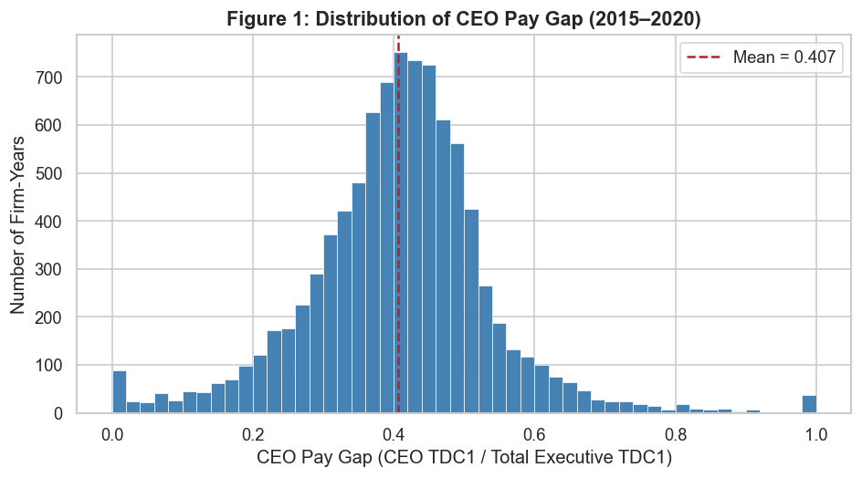

```python
# Figure 1: Distribution of CEO Pay Gap
fig, ax = plt.subplots(figsize=(8, 4.5))
ax.hist(df['ceo_pay_gap'], bins=50, color='steelblue', edgecolor='white', linewidth=0.4)
ax.axvline(df['ceo_pay_gap'].mean(), color='firebrick', linestyle='--', linewidth=1.5,
           label=f"Mean = {df['ceo_pay_gap'].mean():.3f}")
ax.set_xlabel('CEO Pay Gap (CEO TDC1 / Total Executive TDC1)', fontsize=12)
ax.set_ylabel('Number of Firm-Years', fontsize=12)
ax.set_title('Figure 1: Distribution of CEO Pay Gap (2015–2020)', fontsize=13, fontweight='bold')
ax.legend()
plt.tight_layout()
plt.savefig('fig1_pay_gap_dist.png', dpi=150)
plt.show()
```

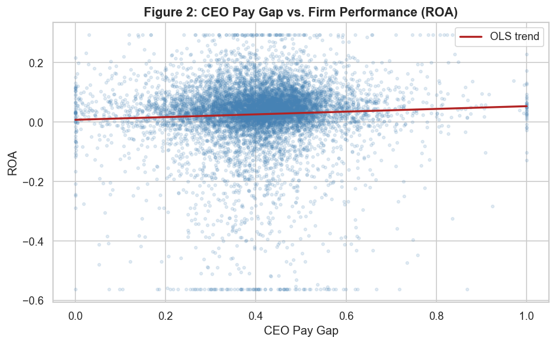

```python
# Figure 2: Scatter Plot — CEO Pay Gap vs ROA
fig, ax = plt.subplots(figsize=(8, 5))
ax.scatter(df['ceo_pay_gap'], df['roa'], alpha=0.15, s=8, color='steelblue')

# Add OLS trend line
z = np.polyfit(df['ceo_pay_gap'], df['roa'], 1)
p = np.poly1d(z)
x_range = np.linspace(df['ceo_pay_gap'].min(), df['ceo_pay_gap'].max(), 200)
ax.plot(x_range, p(x_range), color='firebrick', linewidth=2, label='OLS trend')

ax.set_xlabel('CEO Pay Gap', fontsize=12)
ax.set_ylabel('ROA', fontsize=12)
ax.set_title('Figure 2: CEO Pay Gap vs. Firm Performance (ROA)', fontsize=13, fontweight='bold')
ax.legend()
plt.tight_layout()
plt.savefig('fig2_scatter.png', dpi=150)
plt.show()
```

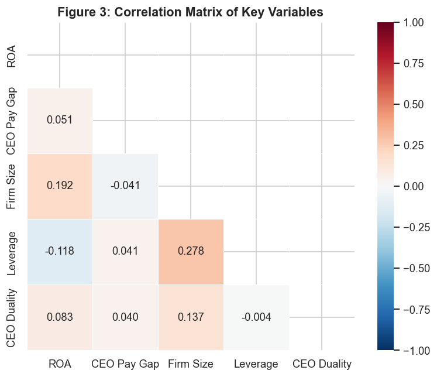

```python
# Figure 3: Correlation Heatmap
corr_labels = {
    'roa': 'ROA',
    'ceo_pay_gap': 'CEO Pay Gap',
    'firm_size': 'Firm Size',
    'leverage': 'Leverage',
    'ceo_duality': 'CEO Duality'
}
corr_df = df[key_vars].rename(columns=corr_labels)
corr_matrix = corr_df.corr()

fig, ax = plt.subplots(figsize=(7, 5.5))
mask = np.triu(np.ones_like(corr_matrix, dtype=bool))
sns.heatmap(corr_matrix, annot=True, fmt='.3f', cmap='RdBu_r',
            center=0, square=True, linewidths=0.5,
            ax=ax, mask=mask, vmin=-1, vmax=1)
ax.set_title('Figure 3: Correlation Matrix of Key Variables', fontsize=13, fontweight='bold')
plt.tight_layout()
plt.savefig('fig3_heatmap.png', dpi=150)
plt.show()
```

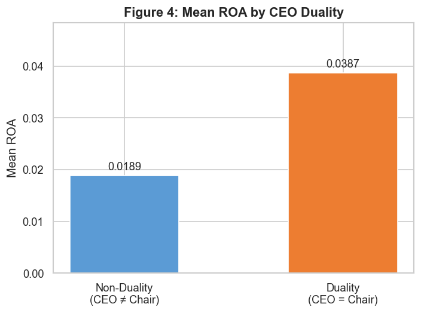

```python
# Figure 4: Mean ROA by CEO Duality
duality_roa = df.groupby('ceo_duality')['roa'].mean().reset_index()
duality_roa['label'] = duality_roa['ceo_duality'].map({0: 'Non-Duality\n(CEO ≠ Chair)', 1: 'Duality\n(CEO = Chair)'})

fig, ax = plt.subplots(figsize=(6, 4.5))
bars = ax.bar(duality_roa['label'], duality_roa['roa'], color=['#5B9BD5', '#ED7D31'],edgecolor='white', width=0.5)
ax.bar_label(bars, fmt='%.4f', padding=3, fontsize=11)
ax.set_ylabel('Mean ROA', fontsize=12)
ax.set_title('Figure 4: Mean ROA by CEO Duality', fontsize=13, fontweight='bold')
ax.set_ylim(0, duality_roa['roa'].max() * 1.25)
plt.tight_layout()
plt.savefig('fig4_duality_roa.png', dpi=150)
plt.show()
```

## 3.3 Regression Model

To answer our research question, we estimated an **OLS regression** with ROA as the dependent variable:

$$\text{ROA} = \beta_0 + \beta_1(\text{CEO Pay Gap}) + \beta_2(\text{Firm Size}) + \beta_3(\text{Leverage}) + \beta_4(\text{CEO Duality}) + \varepsilon$$

We used heteroscedasticity-robust standard errors rather than the default OLS standard errors. Reason being the residuals showed clear signs of non-constant variance across the range of fitted values and something that's pretty typical with firm-level cross-sectional data, where small and large companies behave quite differently. Using this keeps our hypothesis tests valid and pretty reliable even though that assumption of constant variance doesn't really hold here.

```python
# OLS Regression
X = df[['ceo_pay_gap', 'firm_size', 'leverage', 'ceo_duality']]
X = sm.add_constant(X)
y = df['roa']

model  = sm.OLS(y, X).fit(cov_type='HC3')
print(model.summary(xname=['Intercept', 'CEO Pay Gap', 'Firm Size (log)',
                            'Leverage', 'CEO Duality']))
```

```
                            OLS Regression Results
==============================================================================
Dep. Variable:                    roa   R-squared:                       0.076
Model:                            OLS   Adj. R-squared:                  0.075
Method:                 Least Squares   F-statistic:                     96.29
Date:                Tue, 16 Jun 2026   Prob (F-statistic):           2.26e-80
Time:                        19:00:44   Log-Likelihood:                 6966.2
No. Observations:                9087   AIC:                        -1.392e+04
Df Residuals:                    9082   BIC:                        -1.389e+04
Df Model:                           4
Covariance Type:                  HC3
===================================================================================
                      coef    std err          z      P>|z|      [0.025      0.975]
-----------------------------------------------------------------------------------
Intercept          -0.1043      0.009    -11.376      0.000      -0.122      -0.086
CEO Pay Gap         0.0598      0.010      6.286      0.000       0.041       0.078
Firm Size (log)     0.0167      0.001     16.215      0.000       0.015       0.019
Leverage           -0.0988      0.008    -12.487      0.000      -0.114      -0.083
CEO Duality         0.0111      0.002      4.762      0.000       0.007       0.016
==============================================================================
Omnibus:                     3554.733   Durbin-Watson:                   1.106
Prob(Omnibus):                  0.000   Jarque-Bera (JB):            23362.840
Skew:                          -1.736   Prob(JB):                         0.00
Kurtosis:                      10.047   Cond. No.                         70.8
==============================================================================

Notes:
[1] Standard Errors are heteroscedasticity robust (HC3)
```

# 4. Results and Discussion

[figure not shown]

*Note: Heteroscedasticity-robust standard errors (HC3). \*** p < 0.001. R² = 0.076, Adjusted R² = 0.075, N = 9,087.*

## 4.1 CEO Pay Gap

The headline finding here is that CEO pay gap has a positive and statistically significant relationship with firm performance. The coefficient of 0.060 (p < 0.001) means that if a firm's CEO pay gap increases by 10 percentage points, ROA goes up by roughly 0.6 percentage points where other variables are fixed.

This fits well with tournament theory. A bigger pay differential between the CEO and the rest of the leadership team seems to function as a stronger incentive, motivating the kind of effort and risk taking ability that eventually shows up in better overall firm performance. It's also broadly consistent with what Kale, Reis, and Venkateswaran (2009) found when they looked at similar pay gap effects in US listed firms.

That said, it's worth being honest about the size of this effect. A 10 point shift in the pay gap ratio is a meaningful change in pay structure, but a 0.6 percentage point bump in ROA is small. So while the relationship is statistically real, CEO pay gap on its own clearly isn't a major lever for driving firm performance.

## 4.2 Control Variables

Firm Size coefficient 0.017, p < 0.001 Bigger firms perform a bit better on ROA, which tracks with the usual story. larger companies often have more diversified revenue streams, more bargaining power with suppliers and customers and high benefit from economies of scale.

Leverage coefficient -0.099, p < 0.001 More debt is associated with lower ROA, which makes sense once you remember that interest expense eats directly into net income, and heavily indebted firms often have less room to invest. This is a pretty well-established relationship in the accounting and finance literature.

CEO Duality (coefficient 0.011, p < 0.001) Firms where the CEO also chairs the board show slightly higher ROA on average. One read of this is that combining the roles allows for faster, more decisive leadership ,though it's worth flagging that this cuts against some governance arguments for separating the two roles to maintain independent board oversight, so we wouldn't want to over-interpret a fairly small coefficient.

## 4.3 Overall Model Fit

The R² of 0.076 tells us that our four predictors together explain about 7.6% of the variation in ROA. On its own that number looks low, but it's actually pretty normal for this kind of cross-sectional, firm-level regression in what drives profitability like industry conditions, the broader economy, firm-specific strategy and execution which simply isn't captured by these four variables. The F-statistic of 96.29 where p < 0.001 confirms that, taken together, the model is statistically significant.

# 5. Conclusion

This project set out to examine whether the CEO pay gap is associated with firm performance, using 9,087 firm-year observations taken from Compustat and ExecuComp data covering the period from 2015 to 2020. The findings suggest that a larger CEO pay gap is positively associated with ROA, which is broadly consistent with the predictions of tournament theory.

The key takeaway is that the share of total executive compensation received by the CEO appears to have some relevance for firm performance, even after controlling for firm size, leverage, and CEO duality. Larger firms and those with lower debt levels also tend to perform better, which is generally in line with what we already know about economies of scale and financial risk. CEO duality is linked to a small positive effect on ROA as well, although given the relatively modest coefficient, it would probably be unwise to draw strong conclusions from that result alone.

From a practical perspective, these findings suggest that boards and compensation committees may benefit from focusing not only on CEO pay itself, but also on how that pay compares with compensation across the wider team in terms of exceution. A pay gap that is large enough to provide meaningful incentives, but not that big that it creates perceptions of unfairness among other executives and it may represent a reasonably effective balance.

There are a few limitations worth noting. Industry and year fixed effects were not included in the model, meaning some of the variation currently captured by the error term could potentially be explained by those factors. The relatively low R² also indicates that a substantial amount of variation in firm performance remains unexplained. Future research could explore whether the relationship between CEO pay gap and performance differs across industries or firm sizes, or whether a non-linear model provides a better fit than the relatively simple linear specification used here.

# 6. References

Adams, R. B., & Ferreira, D. (2009). Women in the boardroom and their impact on governance and performance. Journal of Financial Economics, 94(2), 291–309. https://doi.org/10.1016/j.jfineco.2008.10.007

Core, J. E., Holthausen, R. W., & Larcker, D. F. (1999). Corporate governance, chief executive officer compensation, and firm performance. Journal of Financial Economics, 51(3), 371–406. https://doi.org/10.1016/S0304-405X(98)00058-0

Jensen, M. C., & Meckling, W. H. (1976). Theory of the firm: Managerial behavior, agency costs and ownership structure. Journal of Financial Economics, 3(4), 305–360. https://doi.org/10.1016/0304-405X(76)90026-X

Kale, J. R., Reis, E., & Venkateswaran, A. (2009). Rank-order tournaments and incentive alignment: The effect on firm performance. The Journal of Finance, 64(3), 1479–1512. https://papers.ssrn.com/sol3/papers.cfm?abstract_id=1095389

Lazear, E. P., & Rosen, S. (1981). Rank-order tournaments as optimum labor contracts. Journal of Political Economy, 89(5), 841–864. https://doi.org/10.1086/261010

S&P Global Market Intelligence. (2023). Compustat database. S&P Global Market Intelligence. https://www.spglobal.com/marketintelligence

# 7. Contribution Statement

**Prasad Yewle**: Did data preparation and coding components of the project. Tasks included importing and cleaning the Compustat and ExecuComp datasets, merging the data at the firm-year level, constructing all variables, performing descriptive analysis, generating visualisations, running the regression models in collab, and checking the statistical assumptions and outputs.

**Yana Nawargaonkar**: Responsible for the written report and interpretation of results. Tasks included writing the introduction, literature discussion, data preparation section, results and discussion, conclusion, formatting tables and figures, preparing references, and interpreting the regression findings in relation to the research question and relevant literature.